```python
import pandas as pd
import numpy as np
from scipy import stats
import missingno as msno
import joblib
import matplotlib.pyplot as plt
from matplotlib.ticker import FormatStrFormatter
from sklearn.model_selection import train_test_split, cross_validate, cross_val_score
from sklearn.preprocessing import OneHotEncoder, StandardScaler
import seaborn as sns
import subprocess
```

# Загрузка данных

```python
data_hits = pd.read_csv('ga_hits.csv')
```

```python
data_session = pd.read_csv('ga_sessions.csv', dtype='unicode')
```

## Объеденение таблиц

```python
data_merge = pd.merge(data_session, data_hits ,how='inner', left_on = 'session_id', right_on ='session_id')
```

```python
data_merge.shape
```

```
(15685219, 28)
```

## DataPreparation

```python
#check dubl
data_merge[data_merge.duplicated ()]
```

|  | session_id | client_id | visit_date | visit_time | visit_number | utm_source | utm_medium | utm_campaign | utm_adcontent | utm_keyword | ... | hit_date | hit_time | hit_number | hit_type | hit_referer | hit_page_path | event_category | event_action | event_label | event_value |
| --- | --- | --- | --- | --- | --- | --- | --- | --- | --- | --- | --- | --- | --- | --- | --- | --- | --- | --- | --- | --- | --- |

0 rows × 28 columns

```python
data_merge.isnull().sum() / len(data_merge) *100
```

```
session_id                    0.000000
client_id                     0.000000
visit_date                    0.000000
visit_time                    0.000000
visit_number                  0.000000
utm_source                    0.004463
utm_medium                    0.000000
utm_campaign                 14.018759
utm_adcontent                18.057880
utm_keyword                  58.684721
device_category               0.000000
device_os                    58.388614
device_brand                 25.156646
device_model                 99.220368
device_screen_resolution      0.000000
device_browser                0.000000
geo_country                   0.000000
geo_city                      0.000000
hit_date                      0.000000
hit_time                     58.400224
hit_number                    0.000000
hit_type                      0.000000
hit_referer                  39.753975
hit_page_path                 0.000000
event_category                0.000000
event_action                  0.000000
event_label                  23.765572
event_value                 100.000000
dtype: float64
```

```python
# удалим явно не запоненные колонки
data_raw = data_merge.drop(['event_value','device_model'], axis=1)

# удалим cтроки с пропусками в колонке utm_source
data_raw = data_raw[data_raw['utm_source'].notna()]
```

```python
del [[data_session, data_hits, data_merge]]
```

### Генрация фичей соглсно medium_hot source_hot target_hot model_auto

```python
list_organik = ('referral', 'organic','(none)')
list_social = ('QxAxdyPLuQMEcrdZWdWb', 'MvfHsxITijuriZxsqZqt', 'ISrKoXQCxqqYvAZICvjs',
               'IZEXUFLARCUMynmHNBGo', 'PlbkrSYoHuZBWfYjYnfw','gVRrcxiDQubJiljoTbGm'
               )
list_target = ('sub_car_claim_click', 'sub_car_claim_submit_click',
               'sub_open_dialog_click', 'sub_custom_question_submit_click',
               'sub_call_number_click', 'sub_callback_submit_click', 'sub_submit_success',
               'sub_car_request_submit_click')
```

```python
def check_list(data_row):
    check = 1
    for i in list_organik:
        if data_row == i:
            check = 0
    return check

data_raw['medium_hot'] = data_raw['utm_medium'].apply(check_list)
```

```python
def check_list(data_row):
    check = 0
    for i in list_social:
        if data_row == i:
            check = 1
    return check

data_raw['source_hot'] = data_raw['utm_source'].apply(check_list)
```

```python
#data_raw['target_hot'] = 0

def check_list(data_row):
    check = 0
    for i in list_target:
        if data_row == i:
            check = 1
    return check

data_raw['target_hot'] = data_raw['event_action'].apply(check_list)
```

#### model_auto

```python
def get_model(array_element):
    model_split = array_element.split('/')[3:5]
    if len(model_split) == 2:
        model = f'{model_split[0]} {model_split[1]}'
        return model

    return
```

```python
data_raw['model_auto'] = data_raw['hit_page_path'].apply(get_model)
```

#### screen_size

```python
def get_device_screen_resolution(array_element):
    screen_split = array_element.split('x')
    screen_size = int(screen_split[0]) * int(screen_split[1])

    return screen_size
```

```python
data_raw['screen_size'] = data_raw['device_screen_resolution'].apply(get_device_screen_resolution)
```

```python
data_raw = data_raw.drop(['utm_medium', 'utm_source', 'event_action', 'hit_page_path',
                          'device_screen_resolution'], axis=1, errors='ignore')
```

#### device_brand

```python
data_raw.loc[(data_raw['device_category'] =='desktop') &
             (data_raw['device_os'] =='Windows'),['device_brand']]= data_raw.device_brand.fillna('win_desktop')

data_raw.loc[(data_raw['device_category'] =='desktop') &
             (data_raw['device_os'] =='Macintosh'),['device_brand']]= data_raw.device_brand.fillna('apl_desktop')

data_raw.loc[:,['device_brand']]= data_raw.device_brand.fillna('other_desktop')
```

```python
# Удалим обработанные колонки
data_raw_droped = data_raw.drop(['device_os', 'utm_keyword', 'event_category',
                                 'hit_time', 'hit_type', 'event_label'], axis=1, errors='ignore')
```

```python
# Замена пропусков
data_raw_droped.loc[:,['utm_campaign']]= data_raw_droped.utm_campaign.fillna('nun_company')
```

```python
#Нужно уточнить по занчение этого атрибута . Удалим на данном этапе
data_raw_droped = data_raw_droped.drop(['utm_adcontent'], axis=1, errors='ignore')
```

### Удалим дубликаты

```python
data_clear = data_raw_droped.drop_duplicates()
```

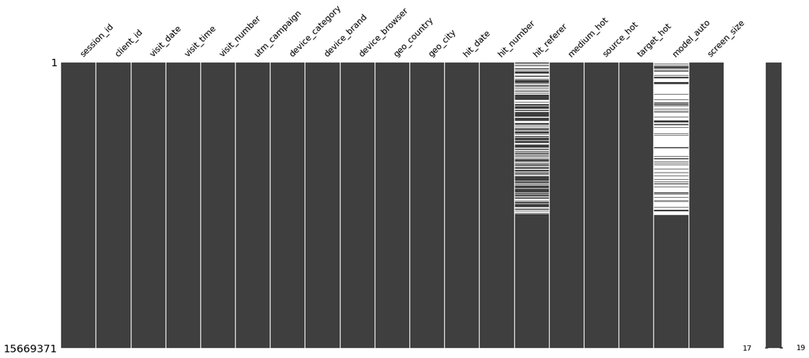

```python
msno.matrix(data_clear);
```

### Приведение сити кантри

```python
data_cleared = data_clear.copy()
```

```python
del [[data_raw, data_raw_droped, data_clear]]
```

```python
data_cleared['geo_city'] = data_cleared.geo_city.apply(lambda x: x.lower())
data_cleared['geo_country'] = data_cleared.geo_country.apply(lambda x: x.lower())
```

```python
data_cleared = data_cleared[data_cleared['geo_country'] == 'russia']

data_cleared = data_cleared.drop(['geo_country'], axis=1, errors='ignore')
```

### Обработка дат

```python
data_cleared[data_cleared['visit_date'] != data_cleared['hit_date']]
```

|  | session_id | client_id | visit_date | visit_time | visit_number | utm_campaign | device_category | device_brand | device_browser | geo_city | hit_date | hit_number | hit_referer | medium_hot | source_hot | target_hot | model_auto | screen_size |
| --- | --- | --- | --- | --- | --- | --- | --- | --- | --- | --- | --- | --- | --- | --- | --- | --- | --- | --- |

```python
data_cleared = data_cleared.drop(['hit_date'], axis=1, errors='ignore')
```

```python
#visit_date
    data_cleared.visit_date = pd.to_datetime(data_cleared.visit_date, utc=True)
```

```python
data_cleared.visit_time = pd.to_datetime(data_cleared.visit_time)
```

```python
data_cleared['visit_time_hour'] = data_cleared['visit_time'].dt.hour
data_cleared = data_cleared.drop(['visit_time'], axis=1, errors='ignore')
#
```

### Приведение численных значений

```python
data_cleared = data_cleared.astype({'visit_number' : np.int64})
data_cleared = data_cleared.astype({'medium_hot' : np.int64})
data_cleared = data_cleared.astype({'source_hot' : np.int64})
```

```python
data_cleared = data_cleared.astype({'client_id' : np.float64})
```

## Выбросы z emissions visit_number & hit_number

```python
df_raw_emission = data_cleared.copy()
```

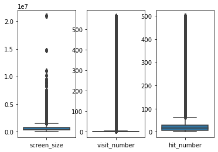

```python
fig, axes = plt.subplots(1, 3)

sns.boxplot(data=df_raw_emission[['screen_size']], ax=axes[0])
sns.boxplot(data=df_raw_emission[['visit_number']], ax=axes[1])
sns.boxplot(data=df_raw_emission[['hit_number']], ax=axes[2]);
```

#### Выбросы hit_number за сеанс

```python
def calculate_outliers(data):
    q25 = data.quantile(0.25)
    q75 = data.quantile(0.75)
    iqr = q75 - q25
    boundaries = (q25 - 1.5 * iqr, q75 + 1.5 * iqr)
    return boundaries
```

```python
boundaries = calculate_outliers(df_raw_emission.hit_number)
is_outlier = (df_raw_emission.hit_number < boundaries[0]) | (df_raw_emission.hit_number > boundaries[1])
is_outlier.sum()
```

```
1021669
```

```python
# Удалим сеансы с аномальными hit_number
df_missing = df_raw_emission[is_outlier]
emission_id = set(df_missing.session_id.unique())
df_raw_emission = df_raw_emission[~df_raw_emission['session_id'].isin(emission_id)]
```

#### Выбросы в количестве визитов

```python
z = stats.zscore(df_raw_emission['visit_number'])
emission_id = {}
df_emission = df_raw_emission[np.abs(z) > 3]
emission_id = set(df_emission.client_id.unique())

df_raw_emission = df_raw_emission[~df_raw_emission['client_id'].isin(emission_id)]
```

#### Выбросы в размере экарна

```python
df_raw_emission = df_raw_emission[df_raw_emission['screen_size'] <= 8294400]
```

```python
df_raw_emission = df_raw_emission.drop(['hit_number'], axis=1, errors='ignore')
```

### Нормализация данных

```python
data_emission = df_raw_emission.copy()
```

```python
std_scaler = StandardScaler()
```

```python
std_scaler.fit(data_emission[['screen_size']])

month_std = std_scaler.transform(data_emission[['screen_size']])

data_emission[['screen_size_std']] = month_std
```

```python
### OneHotEncoder для таргет
```

```python
ohe = OneHotEncoder(sparse=False)
ohe.fit(data_emission[['target_hot']])
ohe_target = ohe.transform(data_emission[['target_hot']])
```

```python
#df_categorical = pd.DataFrame(ohe_target, columns=ohe.get_feature_names_out())
#data_res = pd.concat([data_emission, df_categorical], axis =1)
data_emission[ohe.get_feature_names()] = ohe_target
```

```python
del [[df_raw_emission]]
```

## Correlacion

```python
data_emission.corr()
```

|  | client_id | visit_number | medium_hot | source_hot | target_hot | screen_size | visit_time_hour | screen_size_std | x0_0 | x0_1 |
| --- | --- | --- | --- | --- | --- | --- | --- | --- | --- | --- |
| client_id | 1.000000 | 0.002572 | 0.002144 | -0.001541 | -0.000563 | 0.002664 | 0.002294 | 0.002664 | 0.000563 | -0.000563 |
| visit_number | 0.002572 | 1.000000 | -0.053848 | -0.059314 | 0.019133 | 0.063640 | 0.014049 | 0.063640 | -0.019133 | 0.019133 |
| medium_hot | 0.002144 | -0.053848 | 1.000000 | 0.197626 | -0.006546 | -0.225326 | -0.017121 | -0.225326 | 0.006546 | -0.006546 |
| source_hot | -0.001541 | -0.059314 | 0.197626 | 1.000000 | -0.000266 | 0.001567 | 0.003906 | 0.001567 | 0.000266 | -0.000266 |
| target_hot | -0.000563 | 0.019133 | -0.006546 | -0.000266 | 1.000000 | -0.006387 | -0.001940 | -0.006387 | -1.000000 | 1.000000 |
| screen_size | 0.002664 | 0.063640 | -0.225326 | 0.001567 | -0.006387 | 1.000000 | -0.001985 | 1.000000 | 0.006387 | -0.006387 |
| visit_time_hour | 0.002294 | 0.014049 | -0.017121 | 0.003906 | -0.001940 | -0.001985 | 1.000000 | -0.001985 | 0.001940 | -0.001940 |
| screen_size_std | 0.002664 | 0.063640 | -0.225326 | 0.001567 | -0.006387 | 1.000000 | -0.001985 | 1.000000 | 0.006387 | -0.006387 |
| x0_0 | 0.000563 | -0.019133 | 0.006546 | 0.000266 | -1.000000 | 0.006387 | 0.001940 | 0.006387 | 1.000000 | -1.000000 |
| x0_1 | -0.000563 | 0.019133 | -0.006546 | -0.000266 | 1.000000 | -0.006387 | -0.001940 | -0.006387 | -1.000000 | 1.000000 |

## Ответы для продуктовой команды

#### Трафик города

```python
index = data_emission['geo_city'].value_counts().index[0:4]
df_plot = data_emission[data_emission['geo_city'].isin(index)]
```

```python
data = df_plot.groupby(['geo_city']).agg(({'target_hot': ['sum'],'session_id' : ['count']})).reset_index()
```

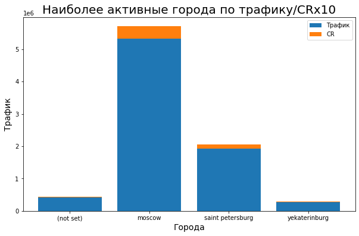

```python
geo = data['geo_city']
trafik = data['session_id']['count']
target = data['target_hot']['sum']

plt.figure(figsize=(10, 6))

plt.bar(geo, trafik, label='Трафик')
plt.bar(geo, target*10, bottom=trafik, label='СR')

plt.xlabel('Города', fontsize=14)
plt.ylabel('Трафик', fontsize=14)
plt.title('Наиболее активные города по трафику/СRx10', fontsize=20)
plt.legend()
plt.show()
```

#### Компании

```python
index = data_emission['utm_campaign'].value_counts().index[0:4]
df_plot = data_emission[data_emission['utm_campaign'].isin(index)]
```

```python
data = df_plot.groupby(['utm_campaign']).agg(({'target_hot': ['sum'],'session_id' : ['count']})).reset_index()
```

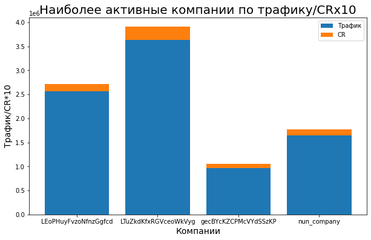

```python
x = data['utm_campaign']
trafik = data['session_id']['count']
target = data['target_hot']['sum']

plt.figure(figsize=(10, 6))

plt.bar(x, trafik, label='Трафик')
plt.bar(x, target*10, bottom=trafik, label='СR')

plt.xlabel('Компании', fontsize=14)
plt.ylabel('Трафик/CR*10', fontsize=14)
plt.title('Наиболее активные компании по трафику/СRx10', fontsize=20)
plt.legend()
plt.show()
```

#### Источник

```python
#df_plot = data_emission[data_emission['hit_referer'].notna()]
index = data_emission['hit_referer'].value_counts().index[0:4]
df_plot = data_emission[data_emission['hit_referer'].isin(index)]
```

```python
data = df_plot.groupby(['hit_referer']).agg(({'target_hot': ['sum'],'session_id' : ['count']})).reset_index()
```

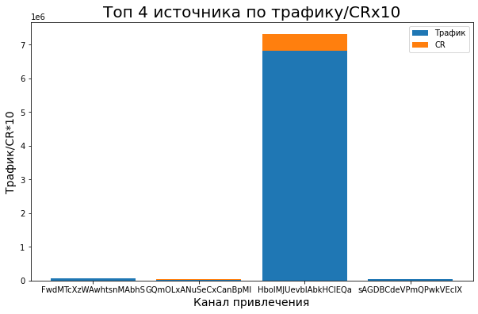

```python
x = data['hit_referer']
trafik = data['session_id']['count']
target = data['target_hot']['sum']

plt.figure(figsize=(10, 6))

plt.bar(x, trafik, label='Трафик')
plt.bar(x, target*10, bottom=trafik, label='СR')

plt.xlabel('Канал привлечения', fontsize=14)
plt.ylabel('Трафик/CR*10', fontsize=14)
plt.title('Топ 4 источника по трафику/СRx10', fontsize=20)
plt.legend()
plt.show()
```

#### Самые популярные модели

```python
index = data_emission['model_auto'].value_counts().index[0:4]
df_plot = data_emission[data_emission['model_auto'].isin(index)]
```

```python
data = df_plot.groupby(['model_auto']).agg(({'target_hot': ['sum'],'session_id' : ['count']})).reset_index()
```

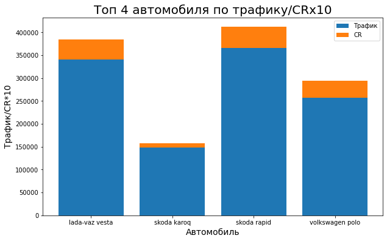

```python
x = data['model_auto']
trafik = data['session_id']['count']
target = data['target_hot']['sum']

plt.figure(figsize=(10, 6))

plt.bar(x, trafik, label='Трафик')
plt.bar(x, target*10, bottom=trafik, label='СR')

plt.xlabel('Автомобиль', fontsize=14)
plt.ylabel('Трафик/CR*10', fontsize=14)
plt.title('Топ 4 автомобиля по трафику/СRx10', fontsize=20)
plt.legend()
plt.show()
```

#### удалим не нужные фичи

```python
data_model = data_emission.drop(['model_auto', 'utm_campaign', 'screen_size_std',
                                    'device_browser', 'screen_size',
                                    'hit_referer', 'device_brand' ], axis=1, errors='ignore')
```

```python
del [[data_emission, df_plot, data]]
```

```python
#data_emission.info()
```

## Data Visualization

```python
df_vizual = data_model[['client_id','visit_number','medium_hot','source_hot','target_hot','session_id','visit_date']]
```

```python
# Группировка по session_id
df = df_vizual.groupby(by=['session_id']).max().reset_index()
```

```python
# Групперовка по дате
df_sum = df.groupby(pd.Grouper(key='visit_date', freq="1D")).agg(({'target_hot': ['sum'],
                                                                   'medium_hot' : ['sum'],
                                                                   'source_hot' : ['sum'],
                                                                   'client_id': ['count'],
                                                                   'session_id' : ['count']})).reset_index()
```

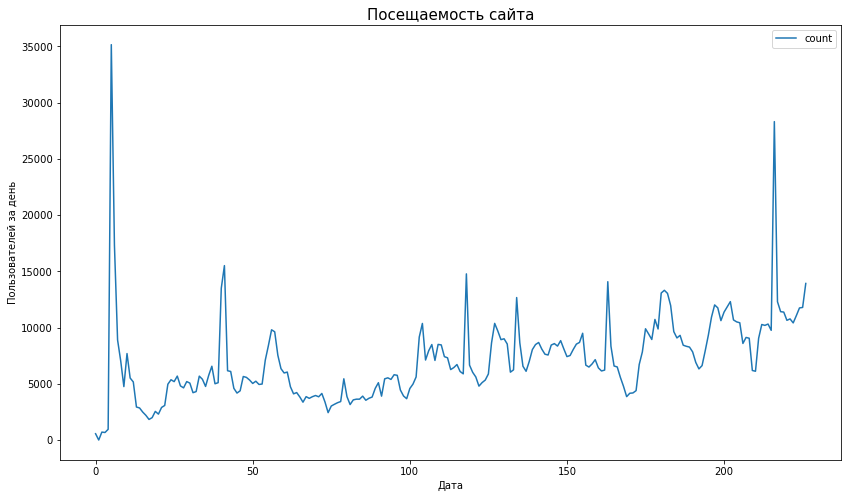

```python
line,ax = plt.subplots(figsize=(14,8))
ax = sns.lineplot(data=df_sum['client_id'])
ax.set_title('Посещаемость сайта', fontsize=15)
ax.set_xlabel ("Дата")
ax.set_ylabel ("Пользователей за день")
ax.legend (loc="upper right");
```

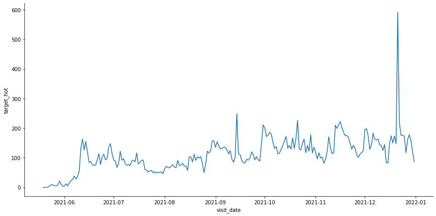

```python
# посмотреть органический трафик 0
organ = df[df['medium_hot'] == 1]
group= organ.groupby(pd.Grouper(key='visit_date', freq="1D")).sum()

sns.relplot(data=group, x="visit_date", y = 'target_hot', kind="line", height=6, aspect=2);
```

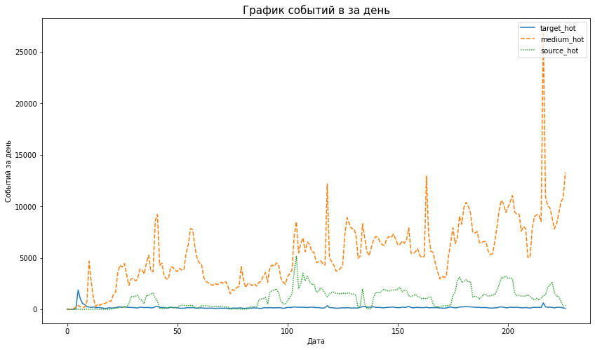

```python
line,ax = plt.subplots(figsize=(14,8))
ax = sns.lineplot(data=df_sum[['target_hot', 'medium_hot', 'source_hot']])
ax.set_title("График событий в за день", fontsize=15)
ax.set_xlabel ("Дата")
ax.set_ylabel ("Событий за день")
ax.legend (loc="upper right");
```

Увеличение количества пользователей не дает значимого прироста лидов  
Возможные причины снижения коневерсии продукта:  
1) Маркетинг: не верно подобрана ЦА аудитория, канал, предложение и т.п.  
**2) Продукт: не соответствует ожиданиям клиента**

# Modeling

```python
def group_day(df1,df2):
    df1 = df1.groupby(pd.Grouper(key='visit_date', freq="1D")).sum().reset_index()
    df2 = df2.groupby(pd.Grouper(key='visit_date', freq="1D")).sum().reset_index()

    return df1,df2
```

```python
def drop_emission(df1,df2):

    boundaries = calculate_outliers(df1.x0_0)
    is_outlier = (df1.x0_0 < boundaries[0]) | (df1.x0_0 > boundaries[1])
    ind_missing = df1[is_outlier].index
    df1 = df1.drop(ind_missing, axis=0)

    boundaries = calculate_outliers(df1.x0_1)
    is_outlier = (df1.x0_1 < boundaries[0]) | (df1.x0_1 > boundaries[1])
    ind_missing = df1[is_outlier].index
    df1 = df1.drop(ind_missing, axis=0)

    boundaries = calculate_outliers(df2.x0_0)
    is_outlier = (df2.x0_0 < boundaries[0]) | (df2.x0_0 > boundaries[1])
    ind_missing = df2[is_outlier].index
    df2 = df2.drop(ind_missing, axis=0)

    boundaries = calculate_outliers(df2.x0_1)
    is_outlier = (df2.x0_1 < boundaries[0]) | (df2.x0_1 > boundaries[1])
    ind_missing = df2[is_outlier].index
    df2 = df2.drop(ind_missing, axis=0)

    return df1,df2
```

```python
def get_feature(df1,df2):
    # Подсчет конверсии CR/трафик
    df1['target_hot'] = df1['x0_1'] / df1['x0_0']
    df2['target_hot'] = df2['x0_1'] / df2['x0_0']

    # Удалим пропуски
    df1 = df1[df1['target_hot'].notna()]
    df2 = df2[df2['target_hot'].notna()]

    # Удалим 0 значения
    df1 = df1[df1['target_hot'] > 0]
    df2 = df2[df2['target_hot'] > 0]

    return df1,df2
```

```python
# Логарифмирование позволяет получить более равномерное распределение
def lg_target(df1,df2):
    df1['target_hot'] = np.log (df1['target_hot'])
    df2['target_hot'] = np.log (df2['target_hot'])

    return df1,df2
```

```python
# Группировка даных по session_id
df_test = data_model.groupby(by=['session_id']).max().reset_index()
```

## Органический трафик не отличается от платного с точки зрения конверсии ?

```python
df_test.info()
```

```
<class 'pandas.core.frame.DataFrame'>
RangeIndex: 1609833 entries, 0 to 1609832
Data columns (total 12 columns):
 #   Column           Non-Null Count    Dtype
---  ------           --------------    -----
 0   session_id       1609833 non-null  object
 1   client_id        1609833 non-null  float64
 2   visit_date       1609833 non-null  datetime64[ns, UTC]
 3   visit_number     1609833 non-null  int64
 4   device_category  1609833 non-null  object
 5   geo_city         1609833 non-null  object
 6   medium_hot       1609833 non-null  int64
 7   source_hot       1609833 non-null  int64
 8   target_hot       1609833 non-null  int64
 9   visit_time_hour  1609833 non-null  int64
 10  x0_0             1609833 non-null  float64
 11  x0_1             1609833 non-null  float64
dtypes: datetime64[ns, UTC](1), float64(3), int64(5), object(3)
memory usage: 147.4+ MB
```

```python
df_hot_f = df_test[df_test['medium_hot'] == 0] # органический трафик
df_hot_t = df_test[df_test['medium_hot'] == 1] # не органиеский трафик
```

```python
df_hot_f,df_hot_t = group_day(df_hot_f,df_hot_t);
```

### Data Cleaning

```python
df_hot_f,df_hot_t = drop_emission(df_hot_f,df_hot_t);
```

### Feature Engineering

```python
df_hot_f,df_hot_t = get_feature(df_hot_f,df_hot_t);
```

```python
df_hot_f,df_hot_t =  lg_target(df_hot_f,df_hot_t );
```

### Data Visualization

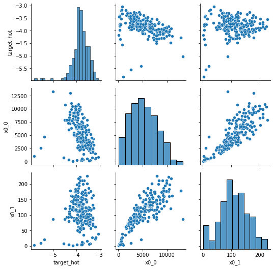

```python
# Построение графиков распределения
g = sns.PairGrid(df_hot_t, vars = ['target_hot','x0_0','x0_1'])
g.map_diag(sns.histplot)
g.map_offdiag(sns.scatterplot);
```

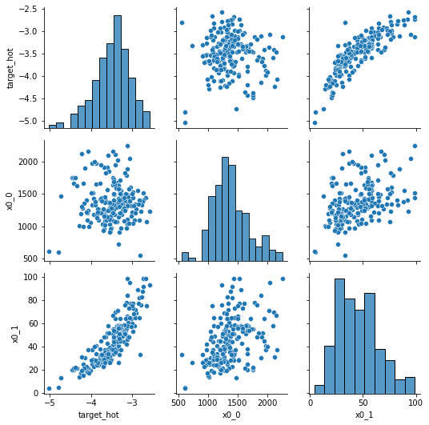

```python
g = sns.PairGrid(df_hot_f, vars = ['target_hot','x0_0','x0_1'])
g.map_diag(sns.histplot)
g.map_offdiag(sns.scatterplot);
```

### Modeling

```python
#  distribution Test shapiro
# H0 данные распределены нормально
stats.shapiro(df_hot_f['target_hot'])
# H0 не подтверждается нормальность распределения
```

```
ShapiroResult(statistic=0.9789794087409973, pvalue=0.0042726206593215466)
```

```python
# H0 данные распределены нормально
stats.shapiro(df_hot_t['target_hot'])
# H0 не подтверждается нормальность распределения
```

```
ShapiroResult(statistic=0.8821741342544556, pvalue=3.92982044475354e-12)
```

```python
# тест на равенство дисперсий
#H0 дисперсии равны

stats.levene(df_hot_t['target_hot'], df_hot_f['target_hot'])

# Дисперсия выборок не равны
```

```
LeveneResult(statistic=12.091443441698791, pvalue=0.0005593801428396207)
```

df_hot_f органический трафик  
**df_hot_t не органический трафик**

```python
# H0 органический трафик не отличатся по конверсии
# H1 конверсия органического трафика отличатся от органического
stats.ttest_ind(df_hot_f['target_hot'], df_hot_t['target_hot'], equal_var=True)
# H1 конверсия органического трафика отличатся от органического pvalue=1.7369139832517727e-17
```

```
Ttest_indResult(statistic=8.896231696851004, pvalue=1.7369139832517727e-17)
```

```python
# H0 органический трафик не отличатся по конверсии
# H1 конверсия не органического трафика меньше органического
stats.ttest_ind(df_hot_t['target_hot'], df_hot_f['target_hot'], equal_var=True, alternative='less')
# H1 конверсия не органического трафика меньше органического
```

```
Ttest_indResult(statistic=-8.896231696851004, pvalue=8.684569916258864e-18)
```

#### Манна — Уитни

```python
# H0 органический трафик не отличатся
# H1 органический трафик отличатся от неорганического
stats.mannwhitneyu(df_hot_f['target_hot'], df_hot_t['target_hot'], alternative='two-sided')
#https://habr.com/ru/company/avito/blog/709596/
# H1 органический трафик отличатся от неорганического pvalue=1.1216843524714885e-18
```

```
MannwhitneyuResult(statistic=33237.5, pvalue=1.1216843524714885e-18)
```

```python
# H0 органический трафик не отличатся по конверсии
# H1 конверсия органический трафика выше не органического
stats.mannwhitneyu(df_hot_f['target_hot'], df_hot_t['target_hot'], alternative='greater')
# H1 конверсия органического трафика больше не органического  pvalue=5.608421762357442e-19
```

```
MannwhitneyuResult(statistic=33237.5, pvalue=5.608421762357442e-19)
```

**Конверсия органического трафика выше не органического**

**После такого вывода в отдел маркетинга лучше не заходить!**

## Трафик с мобильных устройств не отличается с десктопных ?

```python
df_hot_mob = df_test[df_test['device_category'] == 'mobile']
df_hot_des = df_test[df_test['device_category'] == 'desktop']
```

### Data Cleaning | Feature Engineering

```python
df_hot_mob,df_hot_des = group_day(df_hot_mob,df_hot_des)

df_hot_mob,df_hot_des = drop_emission(df_hot_mob,df_hot_des)

df_hot_mob,df_hot_des = get_feature(df_hot_mob,df_hot_des)

df_hot_mob,df_hot_des = lg_target(df_hot_mob,df_hot_des)
```

```python
### Data Visualization
```

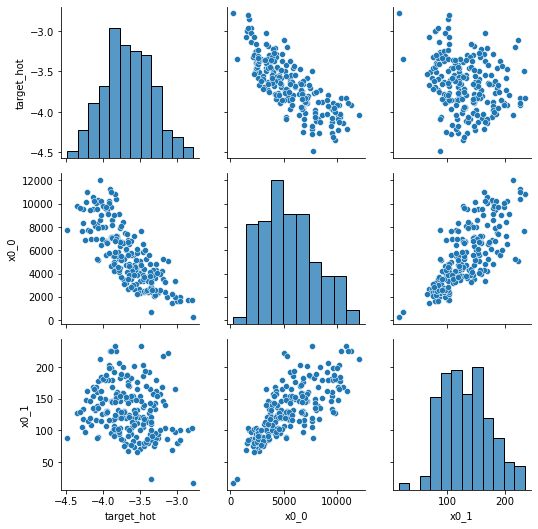

```python
g = sns.PairGrid(df_hot_mob, vars = ['target_hot','x0_0','x0_1'])
g.map_diag(sns.histplot)
g.map_offdiag(sns.scatterplot);
```

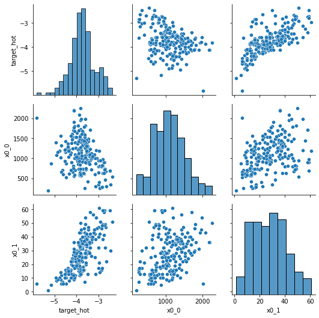

```python
g = sns.PairGrid(df_hot_des, vars = ['target_hot','x0_0','x0_1'])
g.map_diag(sns.histplot)
g.map_offdiag(sns.scatterplot);
```

### Modeling

```python
#  distribution Test shapiro
# H0 данные распределены нормально
stats.shapiro(df_hot_mob['target_hot'])
# H0 подтверждается  pvalue=0.605025410
```

```
ShapiroResult(statistic=0.9944372177124023, pvalue=0.6050254106521606)
```

```python
# H0 данные распределены нормально
stats.shapiro(df_hot_des['target_hot'])
# H0 не подтверждается pvalue=0.0176
```

```
ShapiroResult(statistic=0.9837180972099304, pvalue=0.01767282746732235)
```

```python
# H0 дисперсии равны
stats.levene(df_hot_mob['target_hot'], df_hot_des['target_hot'])

# Дисперсия выборок не равны
```

```
LeveneResult(statistic=29.390181026180567, pvalue=9.988802550025588e-08)
```

```python
# H0 конверсия не зависит от устройства Т -Тест
stats.ttest_ind(df_hot_mob['target_hot'], df_hot_des['target_hot'], equal_var=True)
# H0 подтверждается
```

```
Ttest_indResult(statistic=1.8001160449748457, pvalue=0.07255805165585819)
```

#### Манна-Уитни тест

```python
# H0 конверсия не зависит от устройства Ман-Утни
stats.mannwhitneyu(df_hot_mob['target_hot'], df_hot_des['target_hot'])
#https://habr.com/ru/company/avito/blog/709596/
# H0 подтверждается
```

```
MannwhitneyuResult(statistic=24737.5, pvalue=0.05762788493792235)
```

**Конверсия не зависит от типа устройства**

## Конверсия по городам присутствия не отличается?

```python
df_hot_cap = df_test[(df_test['geo_city'] == 'moscow') | (df_test['geo_city'] == 'saint petersburg')]
df_hot_oth = df_test[~df_test.index.isin(df_hot_cap.index)]
```

#### Data prep | Feature

```python
df_hot_cap,df_hot_oth = group_day(df_hot_cap,df_hot_oth)

df_hot_cap,df_hot_oth = drop_emission(df_hot_cap,df_hot_oth)

df_hot_cap,df_hot_oth = get_feature(df_hot_cap,df_hot_oth)

df_hot_cap,df_hot_oth = lg_target(df_hot_cap,df_hot_oth)
```

### Data Visualization

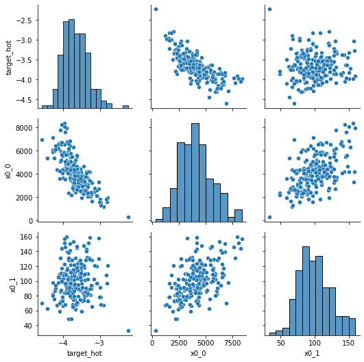

```python
# Построение графиков распределения
g = sns.PairGrid(df_hot_cap, vars = ['target_hot','x0_0','x0_1'])
g.map_diag(sns.histplot)
g.map_offdiag(sns.scatterplot);
```

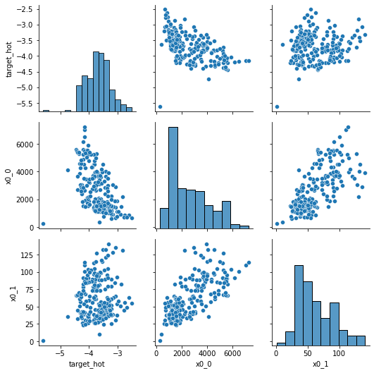

```python
# Построение графиков распределения
g = sns.PairGrid(df_hot_oth, vars = ['target_hot','x0_0','x0_1'])
g.map_diag(sns.histplot)
g.map_offdiag(sns.scatterplot);
```

```python
df_hot_cap['client_id']. isin (df_hot_oth['client_id']). value_counts ()
# Будем считать не зависимыми
```

```
False    212
Name: client_id, dtype: int64
```

### Modeling

```python
#  distribution Test shapiro
# H0 данные распределены нормально
stats.shapiro(df_hot_oth['target_hot'])
# H0 не подтверждается pvalue <5%
```

```
ShapiroResult(statistic=0.9809318780899048, pvalue=0.00480407802388072)
```

```python
# H0 данные распределены нормально
stats.shapiro(df_hot_cap['target_hot'])
# H0 не подтверждается pvalue <5%
```

```
ShapiroResult(statistic=0.9815994501113892, pvalue=0.007192518562078476)
```

```python
# H0 дисперсии равны
stats.levene(df_hot_cap['target_hot'], df_hot_oth['target_hot'])

# Дисперсия выборок не равны
```

```
LeveneResult(statistic=7.370130116674544, pvalue=0.006899786736470587)
```

```python
# H0 трафик СА не зависит географии Т -Тест
stats.ttest_ind(df_hot_cap['target_hot'], df_hot_oth['target_hot'], equal_var=True)
# H0 подтверждается pvalue=0.332
```

```
Ttest_indResult(statistic=0.9702609671689019, pvalue=0.33246441340780264)
```

#### Mannwhitneyu Test

```python
# H0 конверсия не зависит от географии U Test
# H1  трафик СА зависит от географии U Test
stats.mannwhitneyu(df_hot_cap['target_hot'], df_hot_oth['target_hot'])
# H0 конверсия не зависит от географии U Test pvalue=0.533
```

```
MannwhitneyuResult(statistic=23911.5, pvalue=0.5331116672688856)
```

**Конверсия трафика не отличается по городам присутствия**

## Стоит ли нам увеличивать своё присутствие в соцсетях и давать там больше рекламы?

```python
# df_hot_socia трафик из соц сетей
# df_hot_other трафик от остольных источников
df_hot_socia = df_test[df_test['source_hot'] == 1]

df_hot_other = df_test[df_test['source_hot'] == 0]
```

```python
df_hot_socia,df_hot_other = group_day(df_hot_socia,df_hot_other)

df_hot_socia,df_hot_other = drop_emission(df_hot_socia,df_hot_other)

df_hot_socia,df_hot_other = get_feature(df_hot_socia,df_hot_other)

df_hot_socia,df_hot_other = lg_target(df_hot_socia,df_hot_other)
```

### Data Visualization

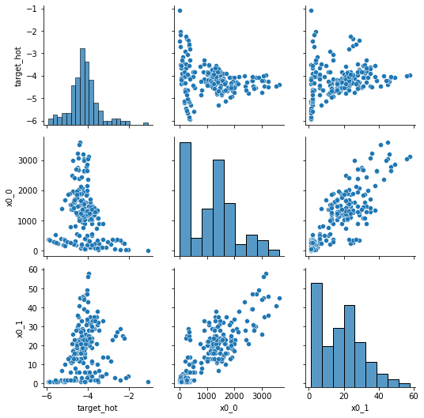

```python
g = sns.PairGrid(df_hot_socia, vars = ['target_hot','x0_0','x0_1'])
g.map_diag(sns.histplot)
g.map_offdiag(sns.scatterplot);
```

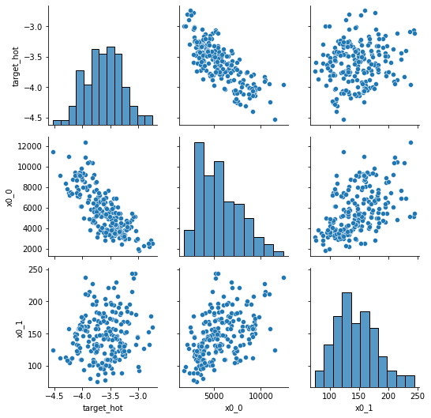

```python
g = sns.PairGrid(df_hot_other, vars = ['target_hot','x0_0','x0_1'])
g.map_diag(sns.histplot)
g.map_offdiag(sns.scatterplot);
```

### Modeling

```python
# H0 данные распределены нормально
stats.shapiro(df_hot_socia['target_hot'])
# H0 не подьверждается pvalue <5%
```

```
ShapiroResult(statistic=0.9416009783744812, pvalue=4.2452731463527016e-07)
```

```python
# H0 данные распределены нормально
stats.shapiro(df_hot_other['target_hot'])
# H0 данные распределены нормально
```

```
ShapiroResult(statistic=0.9952735304832458, pvalue=0.7633807063102722)
```

```python
# H0 дисперсии равны
stats.levene(df_hot_socia['target_hot'], df_hot_other['target_hot'])

# N0 не подтверждается Дисперсия выборок не равны
```

```
LeveneResult(statistic=34.01585203561709, pvalue=1.1247479275781679e-08)
```

```python
# H0 трафик СА не зависит от соц сетей
stats.ttest_ind(df_hot_socia['target_hot'], df_hot_other['target_hot'], equal_var=True)
# H0 не подьверждается
```

```
Ttest_indResult(statistic=-10.592501812439755, pvalue=2.74194737710059e-23)
```

```python
# H0 конверсия не зависит от источника
# H1 конверсия из соцсетей меньше
stats.ttest_ind(df_hot_socia['target_hot'], df_hot_other['target_hot'], equal_var=True ,alternative='less')
# H0 не подтверждается
# H1 принимается Трафик из соц сетей с точки зрения конверсии хуже чем общий
```

```
Ttest_indResult(statistic=-10.592501812439755, pvalue=1.370973688550295e-23)
```

#### U-Test

```python
# H0 конверсия не зависит от источника
# H1 конверсия зависит от источника
stats.mannwhitneyu(df_hot_socia['target_hot'], df_hot_other['target_hot'])
# H1 конверсия зависит от источника
```

```
MannwhitneyuResult(statistic=7187.0, pvalue=2.409560727595744e-29)
```

```python
# H0 конверсия СА не зависит от источника
# H1 конверсия СА из соцсетей меньше
stats.mannwhitneyu(df_hot_socia['target_hot'], df_hot_other['target_hot'], alternative='less')
#https://habr.com/ru/company/avito/blog/709596/
# H1 принимается Трафик из соц сетей с точки зрения конверсии хуже чем общий pvalue=1.204780363797872e-29
```

```
MannwhitneyuResult(statistic=7187.0, pvalue=1.204780363797872e-29)
```

**С точки зрения конверсии реклама в соц сетях менее эффектива чем весь остальной трафик**

# Conclusion

Проведите проверку следующих гипотез:

> Органический трафик не отличается от платного с точки зрения CR (Conversion Rate) в целевые события.

Отличается причем , у платного трафика конверсия меньше

> Трафик с мобильных устройств не отличается от трафика с десктопных устройств с точки зрения CR (Conversion Rate) в целевые события.

Гипотеза подтверждается, действительно трафик с точки зрения конверсии не отличается

> Трафик из городов присутствия (Москва и область, Санкт-Петербург) не отличается от трафика из иных регионов с точки зрения CR (Conversion Rate) в целевые события.

Трафик с точки зрения конверсии по городам присутсвия (Москва и область, Санкт-Петербург) не отличается от трафика из иных регионов

> Дайте ответы на вопросы продуктовой команды: Из каких источников / кампаний / устройств / локаций к нам идёт самый целевой трафик (и с точки зрения объёма трафика, и с точки зрения CR)?

> Какие авто пользуются наибольшим спросом? У каких авто самый лучший показатель CR (Conversion Rate) в целевые события?

Можно посмотреть на соответствующих графиках. .

> Стоит ли нам увеличивать своё присутствие в соцсетях и давать там больше рекламы?

Конверсия из этого источника меньше чем от других источников тем не менее это не говорит о том что размер бюджета на этот канал нужно пересмотреть. Для ответа на это вопрос нужно сравнивать нет только конверсию но и стоимость лида, поэтому нужны дополнительные данные. При необходимости можно посмотреть аналитику в разрезе рекламных кампаний соц. сетей и отобрать наиболее качественные

В целом наблюдается негативная тенденция. Количество лидов не увеличивается, но при этом значительно увеличивается не органический трафик в связи с чем можно сделать вывод о проблемах либо в продукте либо в маркетинге.

```python
!jupyter nbconvert --to html /content/factor_analysis.ipynb
```